# Homework2

## STA 141A: Assignment 2

Jiawei Zhu 923312684

Find and download the billionare dataset from Canvas and the `mpg` dataset in `R`. Use the following code to load the dataset.

```r
library(tidyverse)
load("bil.RData")
bil <- as_tibble(bil)
mpg <- as_tibble(mpg)
```

## Question 1

**(a)** Create a histogram of `worth in billions` with binwidth = 1.

```
   Min. 1st Qu.  Median    Mean 3rd Qu.    Max.
  1.000   1.400   2.000   3.532   3.500  76.000
```

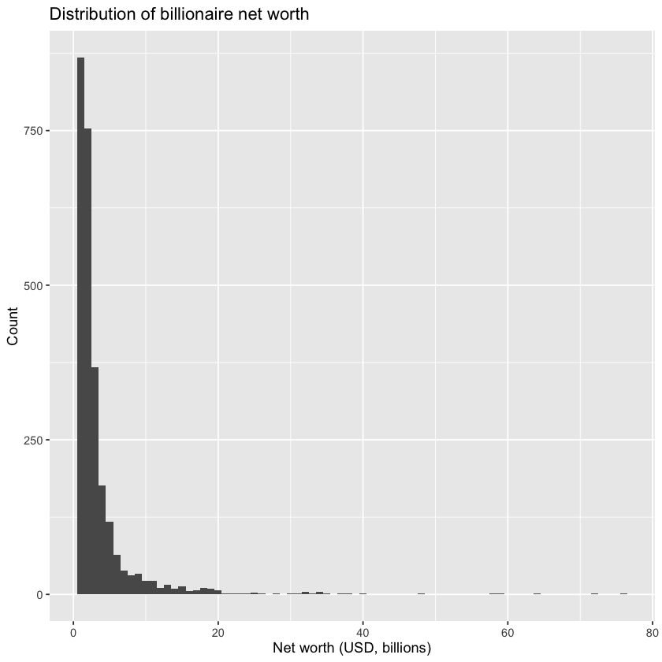

```r
# 1(a)
summary(bil$`worth in billions`)

ggplot(bil) +
  geom_histogram(aes(x = `worth in billions`), binwidth = 1) +
  labs(
    title = "Distribution of billionaire net worth",
    x = "Net worth (USD, billions)",
    y = "Count"
  )
```

**(b)** Based on the histogram, describe the *shape*, *center*, and whether its distribution has a heavy-tail.

# 1(b)

Shape:In the histogram, you can check that the shape is right skewed.

Center:and the mean is 3.532, the median is 2. So that the center of histogram is 2.

Heavy-tail: This is a heavy right-tail.

**(c)** Compute the mean and median of `worth in billions`.

```r
# 1(c)
bil |>
  summarise(
    n = n(),
    mean_networth   = mean(`worth in billions`, na.rm = TRUE),
    median_networth = median(`worth in billions`, na.rm = TRUE),
  )
```

A tibble: 1 × 3

| n <int> | mean_networth <dbl> | median_networth <dbl> |
| --- | --- | --- |
| 2614 | 3.531943 | 2 |

The mean of worth in billions is 3.532. The median of worth in billions is 2.

**(d)** Which measure (e.g., mean, median, quantiles) better represents a “typical” billionaire? Explain briefly.

# 1(d)

The median is better represents a "typical" billionaire. Because the histogram is a right skewed so that high outliers will cause the mean higher. It will less correctly to the center.

## Question 2

**(a)** Create a boxplot of `worth in billions` by `category`, and reorder categories by median using `reorder()`.

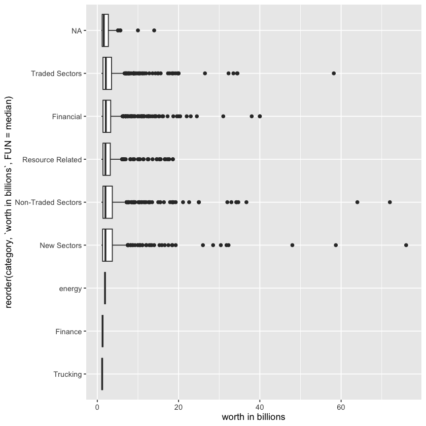

```r
# 2(a)
ggplot(data = bil) +
    geom_boxplot(mapping = aes
    (x = reorder(category, `worth in billions`, FUN = median),
    y = `worth in billions`
    )) +
    coord_flip()
```

**(b)** Which category tends to include the *wealthiest* billionaires? Explain whether your answer relies more on *medians*, *spreads*, or *outliers*.

```r
# 2(b)
bil |>
  group_by(category) |>
  summarise(
    n = n(),
    max_worth   = max(`worth in billions`),
    median_worth = median(`worth in billions`),
  )
```

A tibble: 9 × 4

| category <chr> | n <int> | max_worth <dbl> | median_worth <dbl> |
| --- | --- | --- | --- |
| Finance | 1 | 1.3 | 1.3 |
| Financial | 800 | 40.0 | 2.1 |
| New Sectors | 319 | 76.0 | 2.0 |
| Non-Traded Sectors | 597 | 72.0 | 2.0 |
| Resource Related | 245 | 18.6 | 2.0 |
| Traded Sectors | 564 | 58.2 | 2.1 |
| Trucking | 1 | 1.2 | 1.2 |
| energy | 1 | 1.9 | 1.9 |
| NA | 86 | 14.0 | 1.6 |

In the last question's boxplot and table in here,the wealthiest billionaires is New Sectores. Because most median are really close to 2.0-2.1. But for the max outliets, the New Secotors (76) is extremlly high than others.

## Question 3

We use the `mpg` dataset in this question.

**(a)** Create a scatterplot of `hwy` vs `displ` (engine displacement).

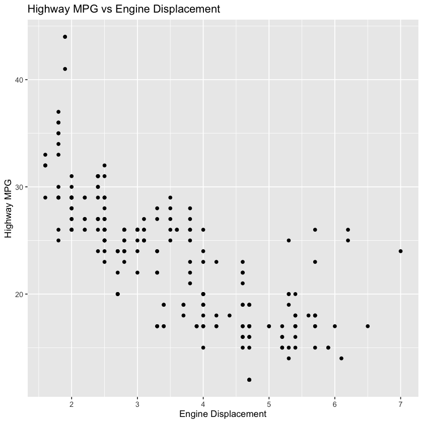

```r
# 3(a)
library(ggplot2)
ggplot(mpg) +
  geom_point(aes(x = displ, y = hwy)) +
  labs(
    title = "Highway MPG vs Engine Displacement",
    x = "Engine Displacement",
    y = "Highway MPG"
  )
```

**(b)** Add color to the points using the variable `class`.

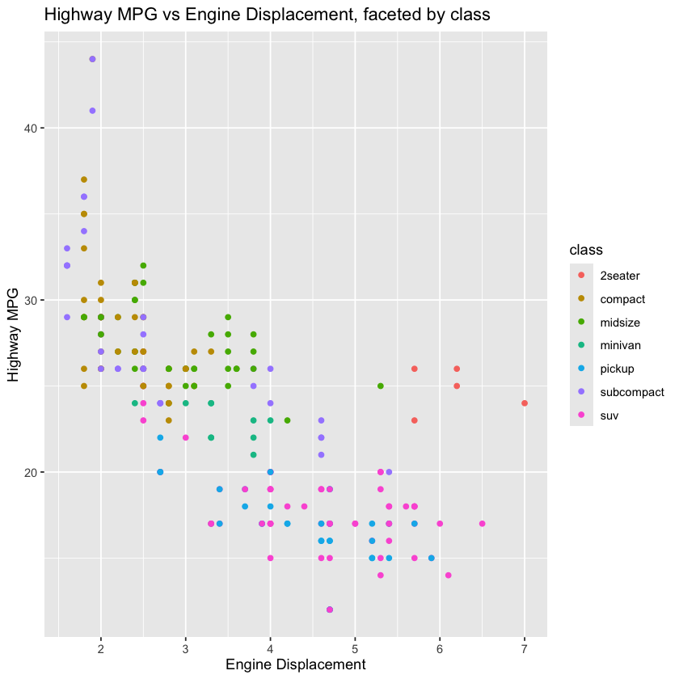

```r
# 3(b)
ggplot(mpg) +
  geom_point(aes(x = displ, y = hwy, color = class)) +
  labs(
    title = "Highway MPG vs Engine Displacement, faceted by class",
    x = "Engine Displacement",
    y = "Highway MPG"
  )
```

**(c)** Describe the relationship between engine size and highway mileage. How do the classes differ?